# pfR

2023-06-25

## State-space models!

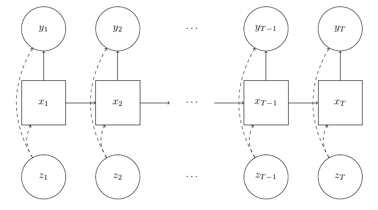

\(\{y_t\}\): time series, \(\{x_t\}\): hidden states, \(\{z_t\}\): inputs

## State-space models

Defining a state-space model requires defining

- \(g(y_t \mid x_t, \theta)\) observation distributions,
- \(f(x_t \mid x_{t-1}, \theta)\) state transition distributions, and
- \(\mu(x_t \mid \theta)\) an initial state distribution.

If you’re Bayesian, you might also pick a prior \(\pi(\theta)\).

## Inference

Statistical inference can target:

- states (assuming parameters are known),
- parameters (ignoring states), or
- both states and parameters simultaneously.

## State Inference

Filtering distributions are

- \(p(x_t \mid y_{1:t}, \theta)\),
- found by recursively applying Bayes’ rule,
- a tool for forecasting, and
- approximated with **weighted samples** in particle filters.

## Parameter Inference

The likelihood \(p(y_{1:T} \mid \theta)\) is *often intractable*!

- Frequentists will have difficulty optimizing it.
- Bayesians will have difficulty integrating it.

Particle filters give us a **random approximate evaluation**.

## Problems

Unfortunately, particle filters are tricky business:

- running them in interpreted languages is slow,
- writing them in compiled code is slow,
- there are so many to choose from, and
- they’re difficult or impossible to parallelize.

## The Solution

`pfR` is the R interface to `pf` (a C++ particle filtering library).

`pf` is fast, but…

- lots of boilerplate
- pure C++

## The Solution

`pfR` automatically generates 99% of the code!

Each model/algorithm pair gets its own class. For each pair, generate

1. a header file,
2. source file with model definition, and
3. export code to use c++ stuff from within R.

## The Solution

Pick an algorithm and name your model by running one of these:

```r
pfr::createSISRFilterTemplate("my_model")
pfr::createAuxiliaryFilterTemplate("my_model")
pfr::createBootstrapFilterTemplate("my_model")
pfr::createBootstrapFilterWithCovTemplate("my_model")
pfr::createRBPFHmmTemplate("my_model")
pfr::createRBPFKalmanTemplate("my_model")
```

and edit `my_model_sisr.h`, `my_model_sisr.cpp` and `my_model_sisr_export.cpp`.

Demo video on the [Github repo](https://github.com/tbrown122387/pfR).

## The Solution

Compile with `Ctrl` + `Shift` + `L` (or `devtools::load_all(".")`)

Run log-likelihood and filtering functions:

```
pfr::my_model_bswc_approx_filt(myData, myParams)
pfr::my_model_bswc_approx_LL(myData, myParams)
```

Demo video on the [Github repo](https://github.com/tbrown122387/pfR).

## Two Examples!

```
## [1] "SPY" "QQQ"
```

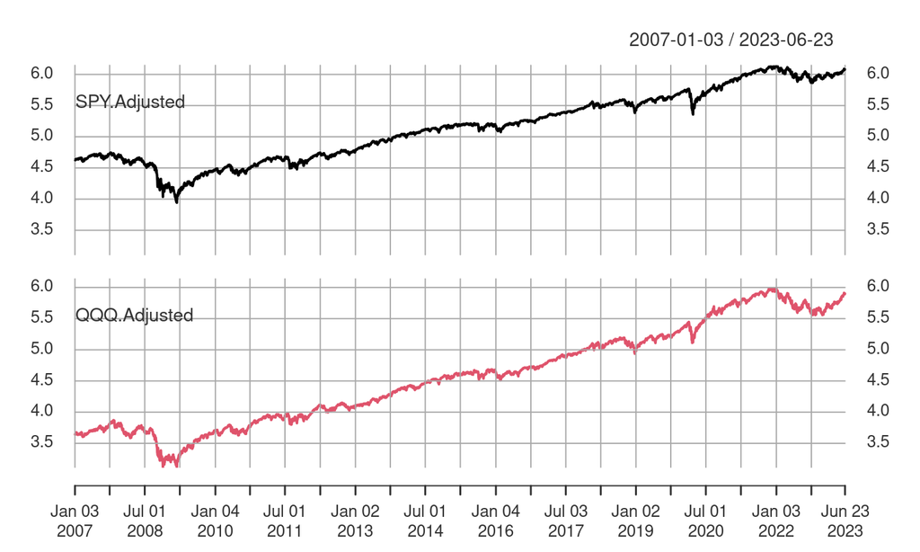

## Univariate Stochastic Volatility

Example: S&P 500 daily returns: \(y_1, y_2, \ldots\)

Randomly changing unobserved log-volatility: \(x_1, x_2, \ldots\)

Downward movements are associated with increases in volatility (vid. Harvey et al. (1996) & Yu (2005))

`createBootstrapFilterWithCovTemplate("svol_leverage")`, edit files, then `Ctrl` + `Shift` + `L` to compile.

## Univariate Stochastic Volatility

\[ \begin{gather*} y_t = \exp(x_t/2)\epsilon_t, \hspace{10mm} t = 1, \ldots, T \\ x_{t+1} = \mu + \phi(x_t - \mu) + \eta_t, \hspace{10mm} t = 1, \ldots, T-1 \\ x_1 \sim \mathcal{N}(\mu, \sigma^2 / (1-\phi^2)) \\ \begin{bmatrix} \epsilon_t \\ \eta_t \end{bmatrix} \sim \mathcal{N}(\boldsymbol{0}, \boldsymbol{\Sigma}) \end{gather*} \]

- \(\mathcal{N}(\cdot, \cdot)\) denotes a normal distribution.
- \(\boldsymbol{\Sigma} = \begin{bmatrix}1 & \rho\sigma \\ \rho\sigma & \sigma^2 \end{bmatrix}\)
- \(\rho\) may or may not be \(0\) (the “leverage effect”)

## Univariate Stochastic Volatility

Step 1: Particle MCMC (Andrieu et al.):

- sample 50k times from \(p(\phi, \mu, \sigma, \rho \mid y_{1:T})\)
- each samples requires running a particle filter over a year of daily returns
- 500 particles for each filter
- \((\hat{\phi}, \hat{\mu}, \hat{\sigma}, \hat{\rho}) = (0.48, .03, 1.49, -.49)\)
- prior from Kim et al. (1998) (\(\rho\) noninformative uniform)

Step 2: filter forward with estimated parameters

## Univariate Stochastic Volatility

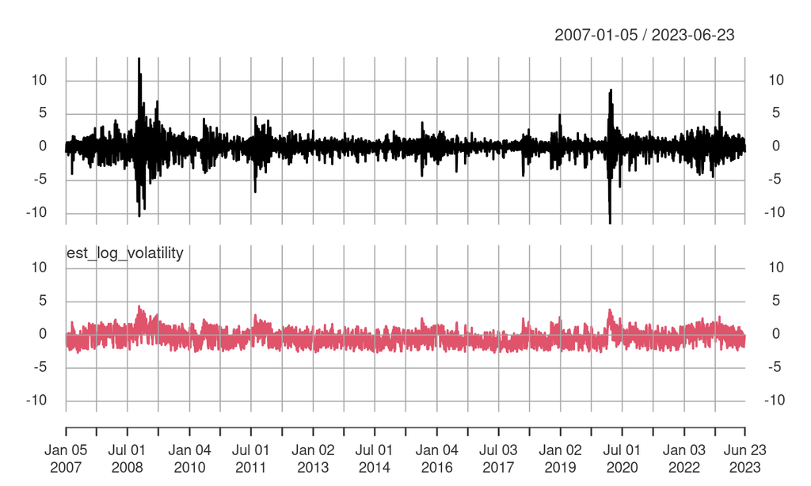

## A Factor Multiv. Stoch. Vol. Model

\[ \begin{gather*} \mathbf{y}_t = \mathbf{B} \mathbf{f}_t + \mathbf{V}_t^{1/2} \boldsymbol{\epsilon}_t, \hspace{10mm} \boldsymbol{\epsilon}_t \sim \mathcal{N}_p(\boldsymbol{0}, \mathbf{I}) \\ \mathbf{f}_t = \mathbf{D}_t^{1/2} \boldsymbol{\gamma}_t, \hspace{10mm} \boldsymbol{\gamma}_t \sim \mathcal{N}_q(\boldsymbol{0}, \mathbf{I}) \\ \mathbf{x}_{t+1} = \boldsymbol{\mu} + \boldsymbol{\Phi} (\mathbf{x}_{t} - \boldsymbol{\mu}) + \boldsymbol{\eta}_t, \hspace{10mm} \boldsymbol{\eta}_t \sim \mathcal{N}_{p+q}(\boldsymbol{0}, \boldsymbol{\Sigma} ) \\\\ \mathbf{x}_1 \sim \mathcal{N}(\boldsymbol{\mu}, \text{diag}(\sigma^2_1/(1-\phi_1^2), \ldots, \sigma^2_{p+q}/(1-\phi_{p+q}^2) ) ) \\ \end{gather*} \]

where \[ \begin{gather*} \mathbf{V}_t = \text{diag}[\exp(x_{1,t}), \ldots, \exp(x_{p,t}) ] \\ \mathbf{D}_t = \text{diag}[\exp(x_{p+1,t}), \ldots, \exp(x_{p+q,t}) ] \\ \boldsymbol{\Phi} = \text{diag}(\phi_1, \ldots, \phi_{p+q}) \\ \boldsymbol{\Sigma} = \text{diag}(\sigma^2_1, \ldots, \sigma^2_{p+q}) \end{gather*} \]

\(p\) is the number of observations, \(q\) is the number of factors.

## A Factor Multiv. Stoch. Vol. Model

Step 1: Particle MCMC:

- log-returns for both SPY and QQQ
- sample 200k times from \(p(\mathbf{B}, \boldsymbol{\mu}, \boldsymbol{\Phi}, \boldsymbol{\Sigma} \mid y_{1:T})\)<sup>1</sup>
- each samples requires running a particle filter over a year of daily returns
- prior motivated from the one above (normal prior for \(\mathbf{B}\) components)
- 100 particles for each filter

Step 2: filter forward with estimated parameters

## A Factor Multiv. Stoch. Vol. Model

- \(\hat{\mathbf{B}} = \begin{bmatrix} 1 & 0 \\ 1.22 & 0 \end{bmatrix}\)
- \(\hat{\boldsymbol{\mu}} = \begin{bmatrix} -1.17 & -.01 & .08 \end{bmatrix}^\intercal\)
- \(\hat{\boldsymbol{\Phi}} = \text{diag}(.85, .84, 0.81)\)
- \(\hat{\boldsymbol{\Sigma}} = \text{diag}(3.72^2, 3.4^2, 3.49^2)\)

## A Factor Multiv. Stoch. Vol. Model

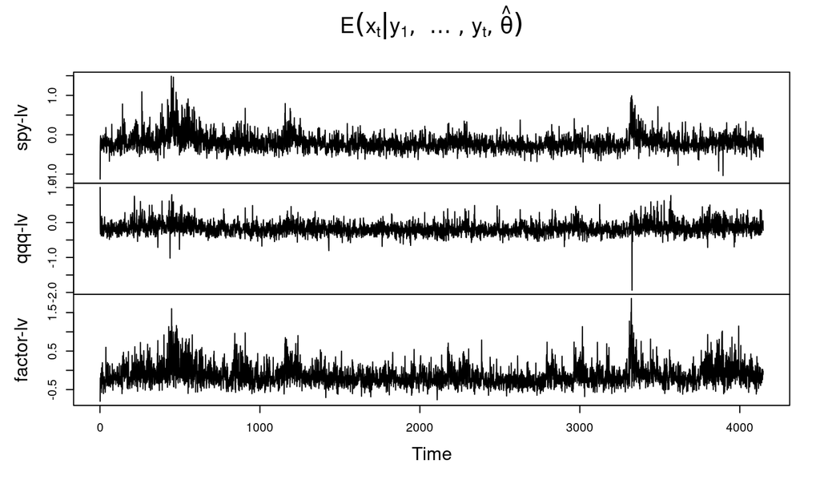

## References (1 of 2)

- S. Chib, Y. Omori, and M. Asai (2009). Multivariate Stochastic Volatility. Handbook of Financial Time Series
- S. Kim, N. Shephard, and S. Chib (1998). Stochastic volatility: likelihood inference and comparison with ARCH models. Review of Economic Studies 65, 361–39
- A.C. Harvey, N. Shephard (1996). The estimation of an asymmetric stochastic volatility model for asset returns. Journal of Business and Economic Statistics 14, 429–434.
- J. Yu, (2005). On leverage in a stochastic volatility model. Journal of Econometrics 127, 165–178.
- M.K. Pitt, and N. Shephard (1999). Time varying covariances: a factor stochastic volatility approach. In: Bernardo, J. M., Berger, J. O., Dawid, A. P. and Smith, A. F. M. (Eds.): Bayesian Statistics 6, 547–570.

## References (2 of 2)

- C Andrieu, and G. Roberts. “The pseudo-marginal approach for efficient Monte Carlo computations.” Ann. Statist. 37 (2) 697 - 725, April 2009. https://doi.org/10.1214/07-AOS574

## Link

Everything available here:

### https://github.com/tbrown122387/pfR/